# Homework 10: Hypothesis Testing

XDASI Fall 2021

05 November, 2021

## COVID-19 cases in NYC

“NYC_covid_cases_by_age.csv” contains weekly data of cases in NYC over the course of the pandemic.

### 1) Import and tidy the data

Convert the data to long format.

- You should preserve the `week_ending` column.
- Get rid of the `age_all_ages` column.
- Convert the rest of the columns to two new columns containing the `age_group` and `cases` information.
- Turn the `age_groups` column into a factor.
- Make sure the `week_ending` column is properly formatted as a Date type.

```r
# import file
nyc_cases<- read.csv("NYC_covid_cases_by_age.csv")

# check structure
str(nyc_cases)
```

```
## 'data.frame':    85 obs. of  12 variables:
##  $ week_ending : chr  "3/14/20" "3/21/20" "3/28/20" "4/4/20" ...
##  $ age_all_ages: num  22.7 221.9 338.1 420.2 413.1 ...
##  $ age_0_4     : num  NA 14.1 23.1 26.2 27.3 ...
##  $ age_5_12    : num  1.07 17.66 19 25.55 31.84 ...
##  $ age_13_17   : num  6.7 57.3 47.4 59.4 68.2 ...
##  $ age_18_24   : num  16.5 148.9 170.6 191.4 200.7 ...
##  $ age_25_34   : num  32.3 259.2 324.6 361.1 327.1 ...
##  $ age_35_44   : num  33.5 321.9 432.1 488 437.5 ...
##  $ age_45_54   : num  28.8 315.2 481.4 607.6 575.4 ...
##  $ age_55_64   : num  26.1 304.4 525.2 667 681.3 ...
##  $ age_65_74   : num  26.4 268.6 490.7 664 650.4 ...
##  $ age_75up    : num  23.1 227.9 546.1 802.7 912.7 ...
```

```r
# convert to long format
nyc_cases_long <- nyc_cases %>% gather("age_group", "cases", -week_ending)
# get rid of what used to be the age_all_ages column
nyc_cases_long <- nyc_cases_long %>% filter(age_group != "age_all_ages")
# format age_group as factor and week_ending as date
nyc_cases_long$age_group<- as.factor(nyc_cases_long$age_group)
nyc_cases_long$week_ending <- as.Date(nyc_cases_long$week_ending, "%m/%d/%y")
```

### 2) Plot cases over time by age group

Create a plot that shows the trajectory of cases over the course of the pandemic for each of the age groups and for all ages combined.

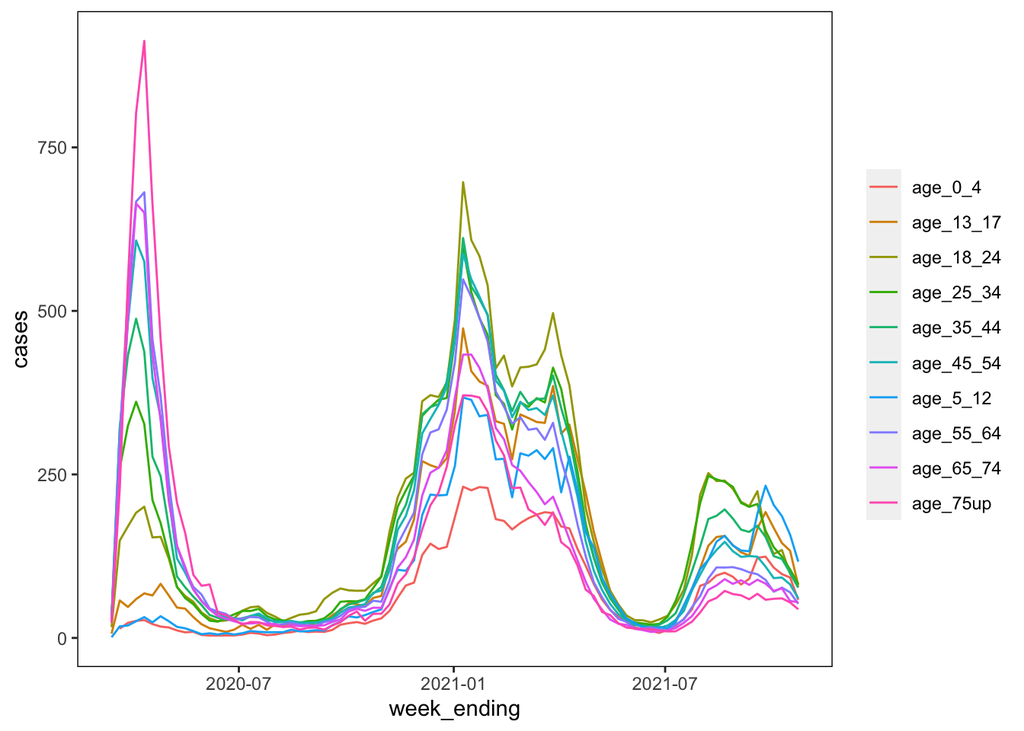

```r
cases_weekly_plot<- ggplot(nyc_cases_long,
                           aes(x=week_ending,
                               y = cases,
                               color= age_group)) +
  geom_line() +
  theme(panel.background=element_blank(),
        strip.background = element_blank(),
        strip.placement = "outside",
        strip.text=element_blank(),
        panel.border=element_rect(colour="black",fill=NA),
        legend.title = element_blank())

cases_weekly_plot
```

### 3) Significance testing

The plot above shows that the number of cases over time forms “waves”. Did the first and the second wave have a similar number of weekly recorded cases in all age groups?

1. Subset the data that corresponds to the first wave. You have to decide for yourself where to draw the cutoffs on the time axis. Then, calculate the total weekly number of cases (sum them up across all age groups). Do the same for the second wave.

```r
first_wave_all_ages <- nyc_cases_long %>%
  filter(week_ending < as.Date("9/1/20", "%m/%d/%y")) %>%
  group_by(week_ending) %>%
  summarize(cases_all_ages = sum(cases))

second_wave_all_ages <- nyc_cases_long %>%
  filter(week_ending >= as.Date("9/1/20", "%m/%d/%y") & week_ending < as.Date("6/1/21", "%m/%d/%y")) %>%
  group_by(week_ending) %>%
  summarize(cases_all_ages = sum(cases))
```

2. Explore the weekly number of cases for the two waves visually using a boxplot, histograms, and qq plots, and perform a test for normality.

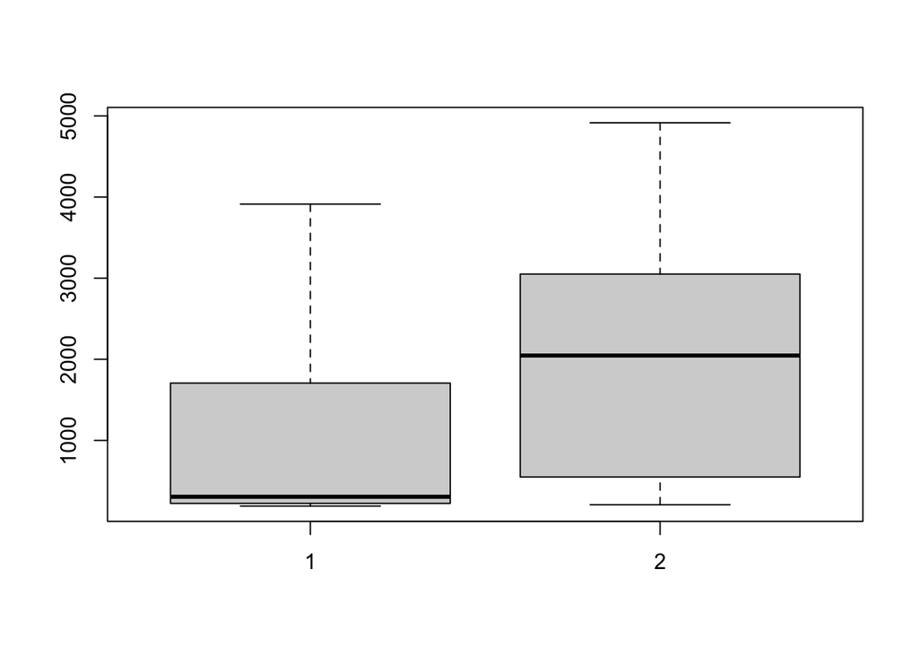

```r
# boxplot
boxplot(first_wave_all_ages$cases_all_ages, second_wave_all_ages$cases_all_ages)
```

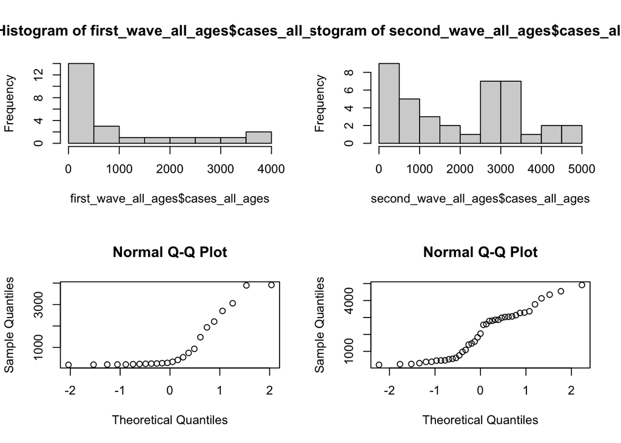

```r
# histograms and qqnorm plots
par(mfrow = c(2,2))
hist(first_wave_all_ages$cases_all_ages,
     breaks = 10)
hist(second_wave_all_ages$cases_all_ages,
     breaks = 10)

qqnorm(first_wave_all_ages$cases_all_ages)
qqnorm(second_wave_all_ages$cases_all_ages)
```

```r
# normality test
shapiro.test(first_wave_all_ages$cases_all_ages)
```

```
##
##  Shapiro-Wilk normality test
##
## data:  first_wave_all_ages$cases_all_ages
## W = 0.71651, p-value = 1.678e-05
```

```r
shapiro.test(second_wave_all_ages$cases_all_ages)
```

```
##
##  Shapiro-Wilk normality test
##
## data:  second_wave_all_ages$cases_all_ages
## W = 0.91062, p-value = 0.004513
```

3. If the data look highly skewed, it might be useful to log-transform the data. Repeat b) for log-transformed data.

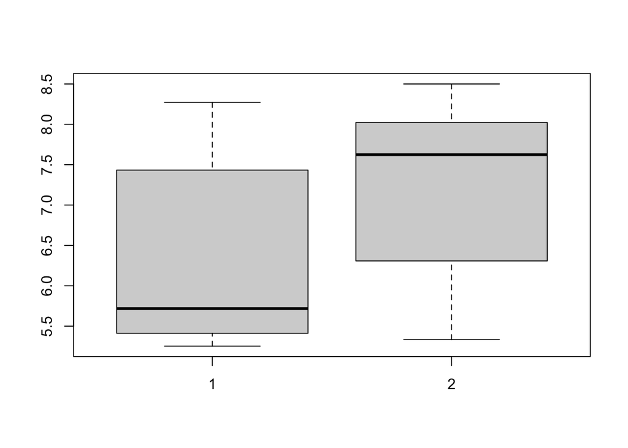

```r
# boxplot
boxplot(log(first_wave_all_ages$cases_all_ages), log(second_wave_all_ages$cases_all_ages))
```

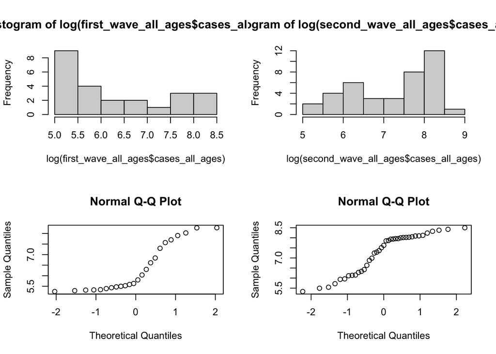

```r
# histograms and qqnorm plots
par(mfrow = c(2,2))
hist(log(first_wave_all_ages$cases_all_ages),
     breaks = 10)
hist(log(second_wave_all_ages$cases_all_ages),
     breaks = 10)

qqnorm(log(first_wave_all_ages$cases_all_ages))
qqnorm(log(second_wave_all_ages$cases_all_ages))
```

```r
# normality test
shapiro.test(log(first_wave_all_ages$cases_all_ages))
```

```
##
##  Shapiro-Wilk normality test
##
## data:  log(first_wave_all_ages$cases_all_ages)
## W = 0.82075, p-value = 0.0006564
```

```r
shapiro.test(log(second_wave_all_ages$cases_all_ages))
```

```
##
##  Shapiro-Wilk normality test
##
## data:  log(second_wave_all_ages$cases_all_ages)
## W = 0.88387, p-value = 0.0007852
```

4. Did the transformation help at all? Run the appropriate statistical test to compare the number of cases in the first and second wave.

```r
wilcox.test(first_wave_all_ages$cases_all_ages, second_wave_all_ages$cases_all_ages)
```

```
##
##  Wilcoxon rank sum exact test
##
## data:  first_wave_all_ages$cases_all_ages and second_wave_all_ages$cases_all_ages
## W = 236, p-value = 0.000808
## alternative hypothesis: true location shift is not equal to 0
```

### 4) Delta strain

We cannot directly compare the number of cases in each age category because we do not know the total number of population in each category (e.g. are there more cases among 75+ year olds than among 0-4 year olds because they get sick more or because there are more of them to begin with?) But we can look whether the **proportion** of cases that fall within each age group (out of the total number of weekly cases summed up across all age groups) differs with time. For example, is there a significant difference between the proportion of infections among 25-34 year-olds before and after the rise of the Delta strain? The Delta strain became prevalent - i.e. started accounting for >50% all cases - on 6/23/21.

1. Convert the weekly number of cases in each group to a proportion of weekly number of cases in all age groups combined. Then, subset the 25-34 age group.

```r
cases_25_34 <- nyc_cases_long %>%
  drop_na() %>%
  group_by(week_ending) %>%
  mutate(prop = cases/sum(cases)) %>%
  filter(age_group == "age_25_34")
```

2. Make a violin plot of the proportion of cases observed per week in the 25-34-year old group before and after the appearance of the Delta variant.

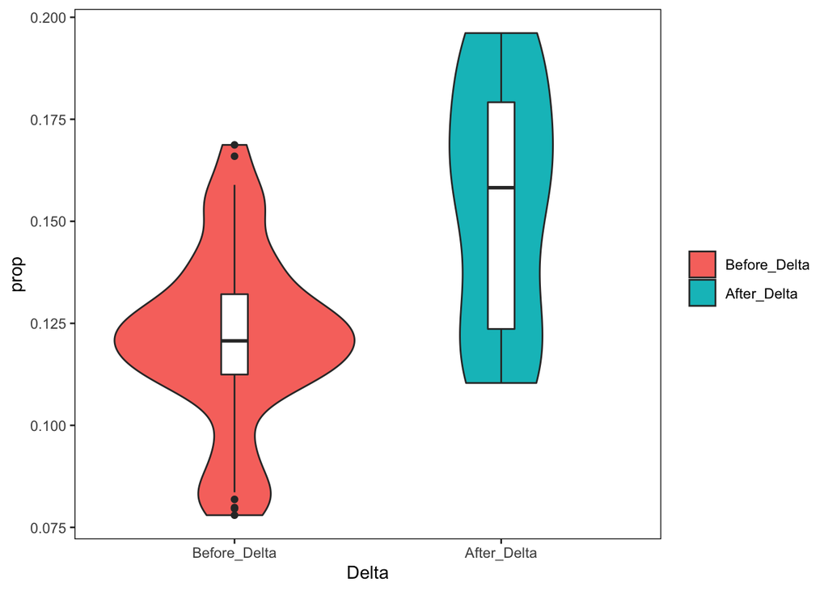

```r
# filter the data
cases_25_34 = cases_25_34 %>%
  mutate(Delta = ifelse(week_ending < as.Date("6/23/21", "%m/%d/%y"), "Before_Delta", "After_Delta"))
cases_25_34$Delta = factor(cases_25_34$Delta,
                           levels=c("Before_Delta","After_Delta"))

# violin plot
ggplot(cases_25_34, aes(x= Delta, y=prop, fill= Delta)) +
  geom_violin() +
  geom_boxplot(width=0.1, fill="white") +
  theme(panel.background=element_blank(),
        strip.background = element_blank(),
        strip.placement = "outside",
        strip.text=element_blank(),
        panel.border=element_rect(colour="black",fill=NA),
        legend.title = element_blank())
```

3. Perform a permutation test for the observed median difference in infection rates in the 25-34 year-old age group before- and after-Delta. Do this using the rates in percentages instead of proportions. What’s the $p$-value you get from the shuffle test?

```r
# convert proportions to percentages
cases_25_34$percent = cases_25_34$prop * 100

# observed difference in rates
obs = diff(mosaic::median(percent ~ Delta, data = cases_25_34))
obs
```

```
## After_Delta
##     3.75334
```

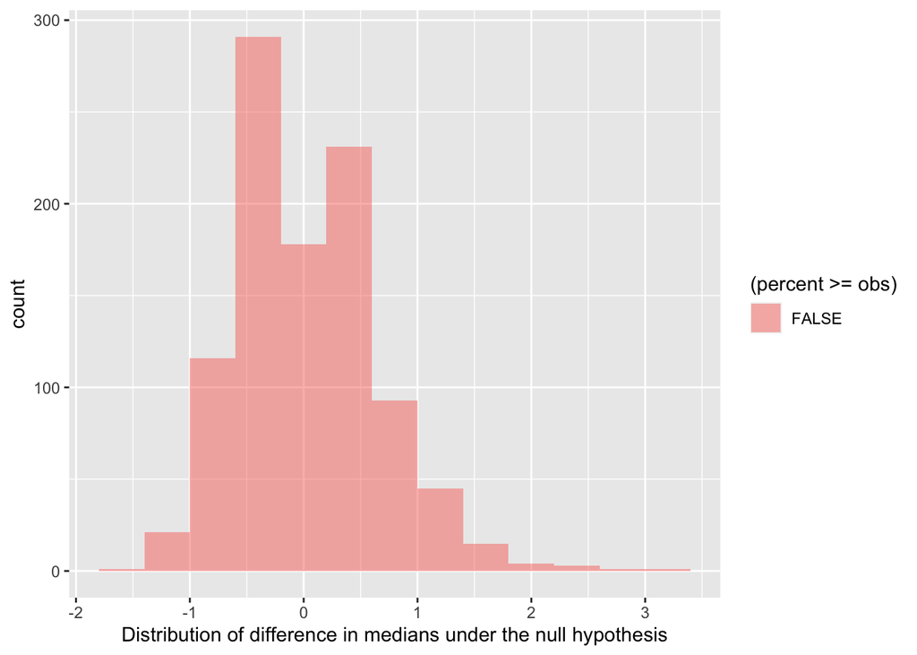

```r
# shuffle test
permute_25_34 = mosaic::do(1000) * diff(mosaic::median(percent ~ shuffle(Delta), data = cases_25_34))
permute_25_34 = permute_25_34 %>% rename(percent = After_Delta)

# draw a histogram
gf_histogram(gformula = ~ percent, fill = ~ (percent >= obs), data = permute_25_34,
  binwidth = 0.4,
  xlab = "Distribution of difference in medians under the null hypothesis")
```

```r
# p-value
p_val = sum(permute_25_34 > obs) / 1000
p_val
```

```
## [1] 0
```

### 5) Breakthrough cases

Consider the following data of the number of NYC documented Covid cases, hospitalizations, and deaths among vaccinated and unvaccinated individuals:

- Cases:
  - Vaccinated: 820
  - Unvaccinated: 4140
- Hospitalizations:
  - Vaccinated: 32
  - Unvaccinated: 349
- Deaths:
  - Vaccinated: 4
  - Unvaccinated: 39

What is an appropriate test you could use to analyze these data? Explain.

```
# your answer here
Either a Fishers Exact Test or a Chi-square test would work here.

Since the numbers are not so big, it is feasible to perform Fishers
and not too computationally intensive. (People tend to forget that Fishers can
be performed on tables that are larger than two-by-two, but it works fine when
the numbers are not too big).
```

Use this data to create a contingency table, and then perform the appropriate test to determine whether there is a significant difference between the vaccinated and unvaccinated groups.

```r
breakthrough_cases = data.frame(Cases = c(820,4140),
                                Hospitalizations = c(32, 349),
                                Deaths = c(4, 39))
row.names(breakthrough_cases) = c("Vaccinated","Unvaccinated")
breakthrough_cases
```

```
##              Cases Hospitalizations Deaths
## Vaccinated     820               32      4
## Unvaccinated  4140              349     39
```

```r
knitr::kable(breakthrough_cases)
```

|  | Cases | Hospitalizations | Deaths |
| --- | --- | --- | --- |
| Vaccinated | 820 | 32 | 4 |
| Unvaccinated | 4140 | 349 | 39 |

```r
fisher.test(breakthrough_cases)
```

```
##
##  Fisher's Exact Test for Count Data
##
## data:  breakthrough_cases
## p-value = 2.324e-05
## alternative hypothesis: two.sided
```

```r
chisq.test(breakthrough_cases)
```

```
##
##  Pearson's Chi-squared test
##
## data:  breakthrough_cases
## X-squared = 18.915, df = 2, p-value = 7.81e-05
```

The tests work the same either way the table is constructed. By convention, we put the groups we want to compare in the rows with the “focal” group first, and the conditions in the columns.

```r
vaccinated<- c(820,32,4)
unvaccinated<- c(4140,349,39)

breakthrough<- data.frame(vaccinated, unvaccinated)
rownames(breakthrough)<- c("cases", "hospitalizations", "deaths")

fisher.test(breakthrough)
chisq.test(breakthrough)
```

[output not shown]